# Health Insurance Report

Viktoriia Tantsiura, Valeriia Zinoveva, Mercédesz Lehoczky

Last edited 2023-03-16 15:03:58

# Health Insurance Dataset Cost Prediction

For Class Exercise 1 we took `health_insurance` dataset from [the Kaggle](https://www.kaggle.com/datasets/annetxu/health-insurance-cost-prediction). The dataset has 1338 observations on insurance expenditure for people of different age, sex, body mass index (BMI) and other.

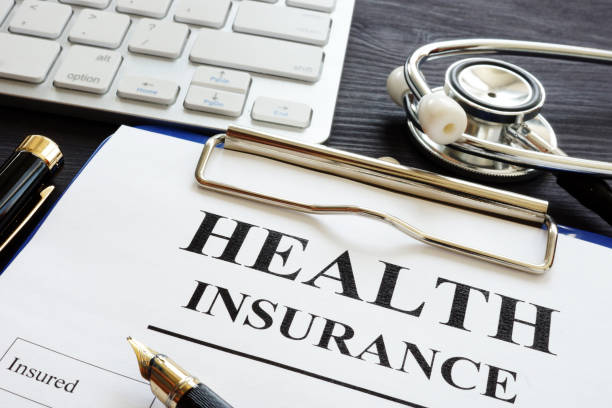

```r
# Browse the dataset
health_insurance
```

```
## # A tibble: 1,338 × 7
##      age sex      bmi children smoker region    charges
##    <dbl> <chr>  <dbl>    <dbl> <chr>  <chr>       <dbl>
##  1    19 female  27.9        0 yes    southwest  16885.
##  2    18 male    33.8        1 no     southeast   1726.
##  3    28 male    33          3 no     southeast   4449.
##  4    33 male    22.7        0 no     northwest  21984.
##  5    32 male    28.9        0 no     northwest   3867.
##  6    31 female  25.7        0 no     southeast   3757.
##  7    46 female  33.4        1 no     southeast   8241.
##  8    37 female  27.7        3 no     northwest   7282.
##  9    37 male    29.8        2 no     northeast   6406.
## 10    60 female  25.8        0 no     northwest  28923.
## # … with 1,328 more rows
```

## Exploratory analysis

```r
# Load packages
library(rio)
library(ggplot2)
library(tidyverse)
library(broom)
library(ggpubr)
library(corrplot)
```

We explored descriptive statistics of different variables included in `health_insurance` and picked the charges as dependent variable and the age and sex as independent variables of interest.

### Expenditure

```r
# Exploring charges as dependent variable
```

```r
summary(health_insurance$charges)
```

```
##    Min. 1st Qu.  Median    Mean 3rd Qu.    Max.
##    1122    4740    9382   13270   16640   63770
```

Now we want to see the distibution of the data.

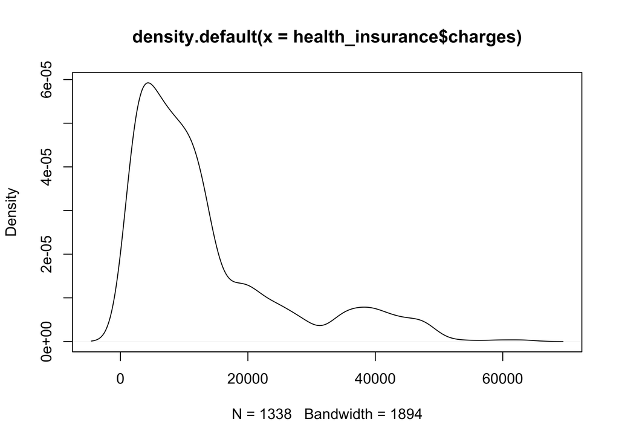

```r
plot(density(health_insurance$charges))
```

The distribution is right-skewed. What is affecting the distribution?

### Age

```r
# Exploring age as independent variable
```

```r
summary(health_insurance$age)
```

```
##    Min. 1st Qu.  Median    Mean 3rd Qu.    Max.
##   18.00   27.00   39.00   39.21   51.00   64.00
```

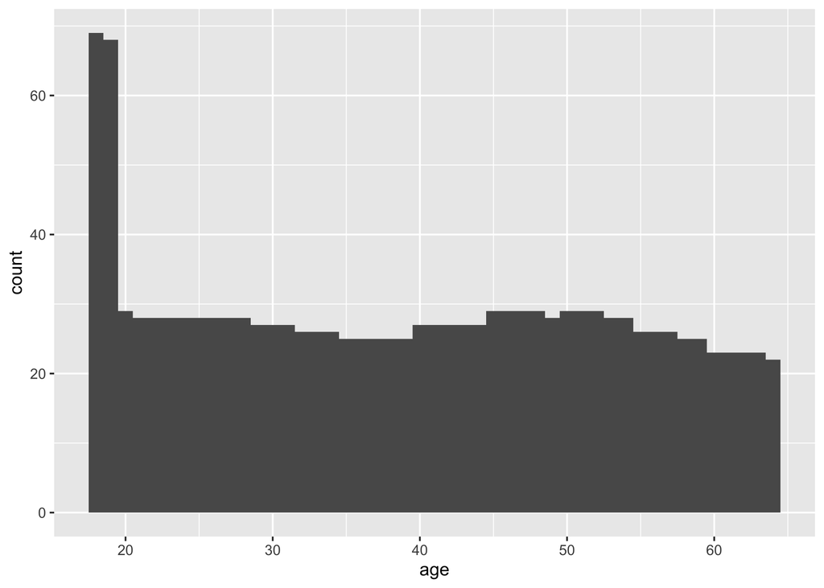

```r
ggplot(health_insurance, aes(age)) +
  geom_histogram(binwidth = 1)
```

The distribution of the age is almost uniform.

### Sex

```r
# Exploring age as independent variable
```

```r
health_insurance$sex <- factor(health_insurance$sex)
summary(health_insurance$sex)
```

```
## female   male
##    662    676
```

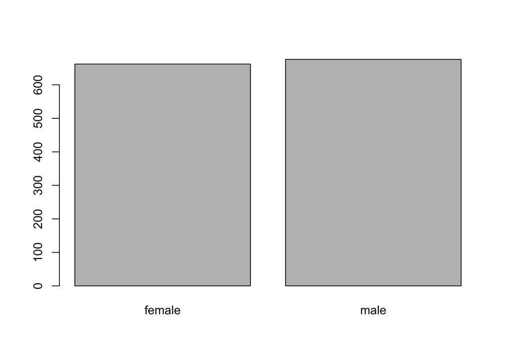

```r
plot(health_insurance$sex)
```

We have almost equal amount of women and men in dataset.

## Hypothesis testing

Let’s assume that age is affecting the health insurance expenditure. It’s a good practice to visualize this thought before making hypothesis.

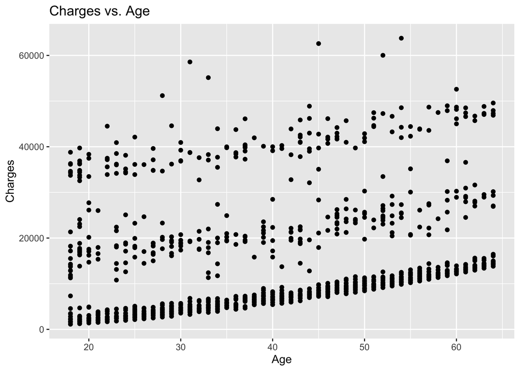

```r
# Making a scatterplot
ggplot(health_insurance, aes(age, charges)) +
  geom_point() +
  labs(x = "Age", y = "Charges") +
  ggtitle("Charges vs. Age")
```

We can see that there is possibly some positive correlation between charges and age.

Will there be any interesting findings if we split by sex?

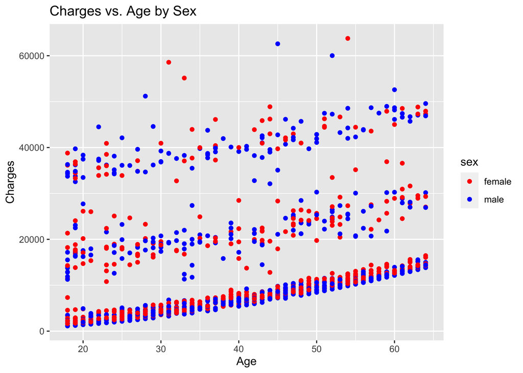

```r
# Split by sex
ggplot(health_insurance, aes(age, charges)) +
  geom_point() +
  labs(x = "Age", y = "Charges") +
  ggtitle("Charges vs. Age by Sex") +
  scale_color_manual(values = c("red", "blue")) +
  aes(color = sex)
```

Even though there may not be a noticeable relationship between the variables of sex and charges, we can still utilize this dataset to improve our data manipulation skills. One way to do this is by isolating the female population and excluding the male observations from our analysis.

### Research question

Do females spend more money on insurance after age of 35?

```r
# Filtering the data
health_insurance_f <- health_insurance %>%
  filter(sex == "female") %>%
  mutate(group = ifelse(age >= 35, "Above 35", "Below 35"))


health_insurance_f %>%
  count(group)
```

```
## # A tibble: 2 × 2
##   group        n
##   <chr>    <int>
## 1 Above 35   396
## 2 Below 35   266
```

```r
# Calculating groupwise summary statistics
health_insurance_f %>%
  group_by(group) %>%
  summarise(mean_charges = mean(charges))
```

```
## # A tibble: 2 × 2
##   group    mean_charges
##   <chr>           <dbl>
## 1 Above 35       15005.
## 2 Below 35        8944.
```

Is this difference is statistically significant or could it be explained by sampling variability?

### Empirical hypothesis

$H_0$ = Females after age 35 spend less than or same amount of money as females before 35 age $H_a$ = Females after age 35 spend more money than females before 35 age

The Welch t-test was chosen to o compare the means between two independent groups.

```r
t.test(charges ~ group, data = health_insurance_f, alternative = "greater")
```

```
##
##  Welch Two Sample t-test
##
## data:  charges by group
## t = 7.116, df = 566.5, p-value = 1.687e-12
## alternative hypothesis: true difference in means between group Above 35 and group Below 35 is greater than 0
## 95 percent confidence interval:
##  4657.308      Inf
## sample estimates:
## mean in group Above 35 mean in group Below 35
##              15004.756               8944.278
```

P-value is less that 0.05, therefore we reject the null hypothesis and conclude that there is evidence to support the alternative hypothesis that females after age 35 spend more money on healthcare expenses than females before 35 years of age. This change is statistically significant and cannot be explained by sampling variability alone.